# Self-Driving Car Engineer Nanodegree

## Project: Build a Traffic Sign Recognition Classifier

In this notebook, a template is provided for you to implement your functionality in stages, which is required to successfully complete this project. If additional code is required that cannot be included in the notebook, be sure that the Python code is successfully imported and included in your submission if necessary.

In addition to implementing code, there is a writeup to complete. The writeup should be completed in a separate file, which can be either a markdown file or a pdf document. There is a [write up template](https://github.com/udacity/CarND-Traffic-Sign-Classifier-Project/blob/master/writeup_template.md) that can be used to guide the writing process. Completing the code template and writeup template will cover all of the [rubric points](https://review.udacity.com/#!/rubrics/481/view) for this project.

The [rubric](https://review.udacity.com/#!/rubrics/481/view) contains "Stand Out Suggestions" for enhancing the project beyond the minimum requirements. The stand out suggestions are optional. If you decide to pursue the "stand out suggestions", you can include the code in this Ipython notebook and also discuss the results in the writeup file.

> **Note:** Code and Markdown cells can be executed using the **Shift + Enter** keyboard shortcut. In addition, Markdown cells can be edited by typically double-clicking the cell to enter edit mode.

```python
# Imports
from scipy import ndimage
from sklearn.utils import shuffle
from tensorflow.contrib.layers import flatten
import csv
import cv2
import math
import matplotlib.pyplot as plt
import numpy as np
import os
import pickle
import tensorflow as tf
import time

# If set to False, i won't visualize results of the code-blocks in the jupyter-notebook.
# Faster for development-purpose
VISUALIZE_DATA = True
```

## Step 0: Load The Data

```python
# Load pickled data

# Path to datasets
training_file = '../data/train.p'
validation_file= '../data/valid.p'
testing_file = '../data/test.p'

# Read in each pickle file step by step
with open(training_file, mode='rb') as f:
    train = pickle.load(f)
with open(validation_file, mode='rb') as f:
    valid = pickle.load(f)
with open(testing_file, mode='rb') as f:
    test = pickle.load(f)

# Get X,Y data for train, validation and testing from readed pickle-files
X_train, y_train = train['features'], train['labels']
X_valid, y_valid = valid['features'], valid['labels']
X_test, y_test = test['features'], test['labels']
```

## Step 1: Dataset Summary & Exploration

The pickled data is a dictionary with 4 key/value pairs:

- `'features'` is a 4D array containing raw pixel data of the traffic sign images, (num examples, width, height, channels).
- `'labels'` is a 1D array containing the label/class id of the traffic sign. The file `signnames.csv` contains id -> name mappings for each id.
- `'sizes'` is a list containing tuples, (width, height) representing the original width and height the image.
- `'coords'` is a list containing tuples, (x1, y1, x2, y2) representing coordinates of a bounding box around the sign in the image. **THESE COORDINATES ASSUME THE ORIGINAL IMAGE. THE PICKLED DATA CONTAINS RESIZED VERSIONS (32 by 32) OF THESE IMAGES**

Complete the basic data summary below. Use python, numpy and/or pandas methods to calculate the data summary rather than hard coding the results. For example, the [pandas shape method](http://pandas.pydata.org/pandas-docs/stable/generated/pandas.DataFrame.shape.html) might be useful for calculating some of the summary results.

### Provide a Basic Summary of the Data Set Using Python, Numpy and/or Pandas

```python
n_test = len(X_test)
n_train = len(X_train)
n_validation = len(X_valid)
image_shape = X_train[0].shape
n_classes = len(np.unique(train['labels']))

print("Data before generating additional data")
print("Number of training examples   =", n_train)
print("Number of testing examples    =", n_test)
print("Number of validation examples =", n_validation)
print("Image data shape              =", image_shape)
print("Number of classes             =", n_classes)
```

```
Data before generating additional data
Number of training examples   = 34799
Number of testing examples    = 12630
Number of validation examples = 4410
Image data shape              = (32, 32, 3)
Number of classes             = 43
```

### Include an exploratory visualization of the dataset

Visualize the German Traffic Signs Dataset using the pickled file(s). This is open ended, suggestions include: plotting traffic sign images, plotting the count of each sign, etc.

The [Matplotlib](http://matplotlib.org/) [examples](http://matplotlib.org/examples/index.html) and [gallery](http://matplotlib.org/gallery.html) pages are a great resource for doing visualizations in Python.

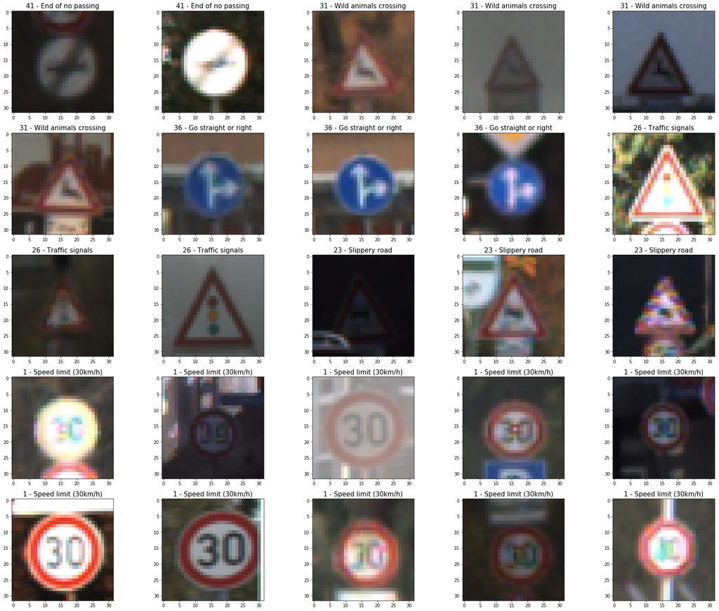

```python
# Visualizations will be shown in the notebook.
%matplotlib inline

# Read in signnames.csv content, which contains the name of each traffic-sign based on the id
trafficSigns = []
with open('./signnames.csv') as csvfile:
    csvreader = csv.reader(csvfile, delimiter=',')
    for row in csvreader:
        trafficSigns.append(row[1])

# Remove headline from label-list
trafficSigns = trafficSigns[1:]

# Returns the name (description of the traffic sign) by the given index
def getSignnameByIndex(idx):
    return trafficSigns[idx]


# Visualization of traffic-sign data:
# The dataset contains the each image within different lightning conditions/resolutions 30times.
# Moreover the images are ordered by type, that why i use the "i * 100" to visualize a variety of examples
# Do visualize different image, i've used the i*30 multiplyer to show more different examples
if VISUALIZE_DATA:
    imgPerRow = 5
    rows = 5
    fig, subplots = plt.subplots(rows, imgPerRow, figsize=(30, 25))
    for i in range(0, rows * imgPerRow):
        imgLabel = train['labels'][i * 150]
        img = train['features'][i * 150]
        subplots[math.floor(i / imgPerRow)][i % imgPerRow].imshow(img)
        subplots[math.floor(i / imgPerRow)][i % imgPerRow].set_title("{} - {}".format(imgLabel, getSignnameByIndex(imgLabel)), fontsize=15)

    fig.savefig('./figures/traffic_sign_dataset_example.png')
```

### Distribution of traffic-sign-image-types

As you can see the histogram below, the amount of traffic-sign images for each type is not even close to be equal. This can cause the network to classify images, which were not as much given as thoose, which were available in much more different variants.

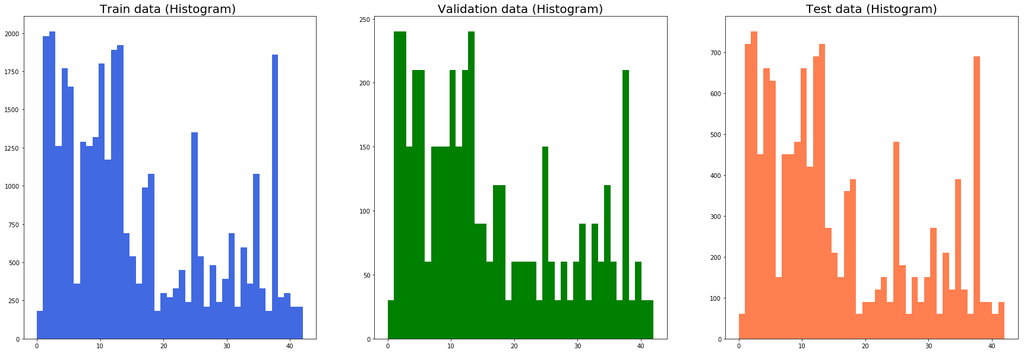

```python
train_labels = train['labels']
valid_labels = valid['labels']
test_labels = test['labels']

# Visualize the amount of images for each type of traffic-sign.
# Contains the visualization for the train-, validation-, test-data
def showHistogramForTrafficSignImages(additional_description=""):
    # Show the latest added images with the respective labels for visualization purpose
    fig, subplots = plt.subplots(1,3,figsize=(30,10))

    subplots[0].hist(train_labels, bins=n_classes, color="royalblue")
    subplots[0].set_title("Train data (Histogram) {}".format(additional_description), fontsize=20)
    subplots[1].hist(valid_labels, bins=n_classes, color="green")
    subplots[1].set_title("Validation data (Histogram)", fontsize=20)
    subplots[2].hist(test_labels, bins=n_classes, color="coral")
    subplots[2].set_title("Test data (Histogram)", fontsize=20)

    return fig


if VISUALIZE_DATA:
    fig = showHistogramForTrafficSignImages()
    fig.savefig("./figures/histogram_without_generated_data.png")
```

To solve the problem, i've added a quite simply image manipulation below, so the traffic-sign types with the lowest amount of images were take and slightly rotated and zoomed, to generate additional images based on the given once. For all given images of the type, i generate a slightly clockwise, anti-clockwise and just zoomed version of the image. Don't forget, that all available images have the exact same resolution of 32x32 pixels, thats why i resized them after rotate or zoomed (crop + resize)

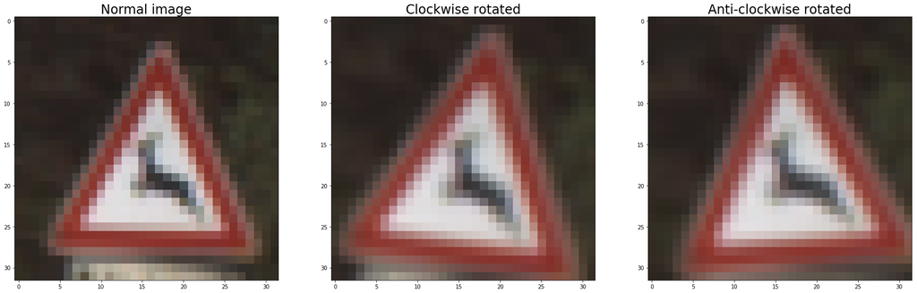

```python
# Rotate, Crops and resizes an image
# Rotation causes non given pixels (in corners) to appear black-colored,
# to avoid black-pixels, the image is cropped and then resized to its original size.
def rotate_image(img, angle=6, crop_pixels=(2,2)):
    # Work on a copy
    copy = np.copy(img)

    # Rotate image by given angle
    # Ref: https://docs.scipy.org/doc/scipy/reference/generated/scipy.ndimage.rotate.html
    rotated = ndimage.rotate(copy, angle, reshape=False)

    # Remove outer pixels of the image
    cropped = rotated[crop_pixels[0]:-crop_pixels[0], crop_pixels[1]:-crop_pixels[1],:]
    return cv2.resize(cropped,(int(32),int(32)))

if VISUALIZE_DATA:
    fig, subplots = plt.subplots(1,3, figsize=(30,10))

    subplots[0].imshow(train['features'][500])
    subplots[0].set_title("Normal image", fontsize=24)
    subplots[1].imshow(rotate_image(train['features'][500], angle=-6))
    subplots[1].set_title("Clockwise rotated", fontsize=24)
    subplots[2].imshow(rotate_image(train['features'][500], angle=6))
    subplots[2].set_title("Anti-clockwise rotated", fontsize=24)

    fig.savefig('./figures/variation_generation_visualized.png')
```

```
X_train.shape (35339, 32, 32, 3)
train_labels.shape (35339,)
X_train.shape (35879, 32, 32, 3)
train_labels.shape (35879,)
X_train.shape (36419, 32, 32, 3)
train_labels.shape (36419,)
X_train.shape (37049, 32, 32, 3)
train_labels.shape (37049,)
X_train.shape (37679, 32, 32, 3)
train_labels.shape (37679,)
X_train.shape (38309, 32, 32, 3)
train_labels.shape (38309,)
X_train.shape (38939, 32, 32, 3)
train_labels.shape (38939,)
X_train.shape (39659, 32, 32, 3)
train_labels.shape (39659,)
X_train.shape (40379, 32, 32, 3)
train_labels.shape (40379,)
X_train.shape (41189, 32, 32, 3)
train_labels.shape (41189,)
```

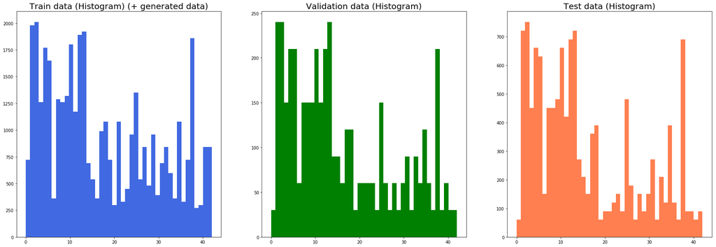

```python
# Iterate through n datasets (traffic-sign-class) with the lowest amount of images
# and generate variations based on the given images
for i in range(0,10):
    # Count the amount of given traffic-sign images for each class
    unique_item, unique_count = np.unique(train_labels, return_counts=True)

    # Get traffic-sign-type (id) with the lowest amount of images from the dataset
    min_label = unique_count.argmin()

    # Get indices of all available images/labels for this traffic-sign-type
    min_label_indices = np.where(train_labels == min_label)[0]

    # Create lists to store the newly generated data
    own_created_images = []
    own_created_labels = []

    # Iterate through all existing images of this type
    for index in min_label_indices:

        # Get the given images from the dataset
        toCopy = X_train[index]

        # Create and append variations (zoomed & 2x rotated)
        own_created_images.append(rotate_image(toCopy, angle=-6)) # Rotate clockwise
        own_created_images.append(rotate_image(toCopy, angle=6))  # Rotate anti clockwise
        own_created_images.append(rotate_image(toCopy, angle=0))  # Just zoomed)

        # Append each label for variant
        own_created_labels.append(min_label)
        own_created_labels.append(min_label)
        own_created_labels.append(min_label)

    # Append new created images to existing list of images
    train_labels = np.append(train_labels, np.array(own_created_labels), axis=0)
    X_train = np.append(X_train, np.array(own_created_images), axis=0)

    # Print out the new shape of the train data/labels to see the new amount of data
    # and to check if the amount is equally sized, which is required
    print("X_train.shape", X_train.shape)
    print("train_labels.shape", train_labels.shape)

if VISUALIZE_DATA:
    fig = showHistogramForTrafficSignImages("(+ generated data)")
    fig.savefig('./figures/histogram_with_generated_data.png')
```

As you can see in the train-data-histogram, the types of traffic-sign images are now all >200, this is caused by adding the slightly modified traffic-signs.

## Step 2: Design and Test a Model Architecture

Design and implement a deep learning model that learns to recognize traffic signs. Train and test your model on the [German Traffic Sign Dataset](http://benchmark.ini.rub.de/?section=gtsrb&subsection=dataset).

The LeNet-5 implementation shown in the classroom at the end of the CNN lesson is a solid starting point. You'll have to change the number of classes and possibly the preprocessing, but aside from that it's plug and play!

With the LeNet-5 solution from the lecture, you should expect a validation set accuracy of about 0.89. To meet specifications, the validation set accuracy will need to be at least 0.93. It is possible to get an even higher accuracy, but 0.93 is the minimum for a successful project submission.

There are various aspects to consider when thinking about this problem:

- Neural network architecture (is the network over or underfitting?)
- Play around preprocessing techniques (normalization, rgb to grayscale, etc)
- Number of examples per label (some have more than others).
- Generate fake data.

Here is an example of a [published baseline model on this problem](http://yann.lecun.com/exdb/publis/pdf/sermanet-ijcnn-11.pdf). It's not required to be familiar with the approach used in the paper but, it's good practice to try to read papers like these.

### Pre-process the Data Set (normalization, grayscale, etc.)

Minimally, the image data should be normalized so that the data has mean zero and equal variance. For image data, `(pixel - 128)/ 128` is a quick way to approximately normalize the data and can be used in this project.

Other pre-processing steps are optional. You can try different techniques to see if it improves performance.

Use the code cell (or multiple code cells, if necessary) to implement the first step of your project.

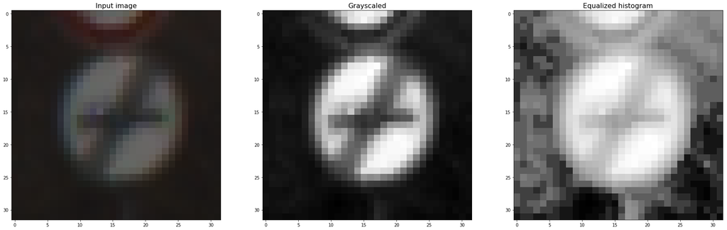

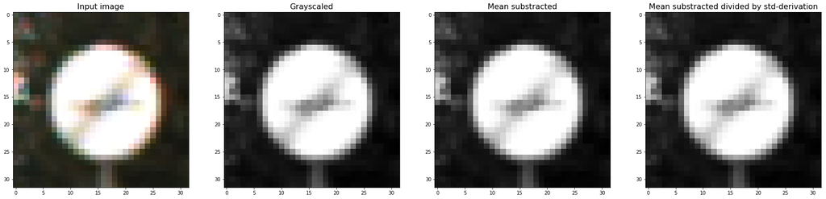

```python
# Normalized value (range -0.5 - +0.5) within the 32x32x1 shape
def normalize_image(rgb_image):
    grayscaled = cv2.cvtColor(rgb_image, cv2.COLOR_RGB2GRAY)

    # Use the cv2 equalizeHist function to equalize the histogram
    # value on the image so the image is more balanced in brightness
    equ_hist = cv2.equalizeHist(grayscaled)

    # Convert value from 0-255 to scale from -0.5 - +0.5
    return ((equ_hist + -128) / 128).reshape(32,32,1)


# During my research on how to improve the image normalization i've discovered the usage of
# np.std (for standard derivation) and np.mean substraction in the following post on stackoverflow
# https://stackoverflow.com/questions/45301648/normalize-the-validation-set-for-a-neural-network-in-keras
# I've tried this normalization which improved my accurancy for the training and validation data ~5%
def normalization_image_improved(rgb_image):
    grayscaled = cv2.cvtColor(rgb_image, cv2.COLOR_RGB2GRAY)
    mean_substracted = grayscaled - np.mean(grayscaled)
    return (mean_substracted / np.std(mean_substracted)).reshape(32,32,1)


# Normalize each image given by the train-dataset
normalized_train = []
for rgb_image in X_train:
    normalized_train.append(normalize_image(rgb_image))

# Normalize each image given by the validation-dataset
normalized_valid = []
for rgb_image in valid['features']:
    normalized_valid.append(normalize_image(rgb_image))

# Normalize each image given by the test-dataset
normalized_test = []
for rgb_image in test['features']:
    normalized_test.append(normalize_image(rgb_image))


# Shuffle all lists
x_train, y_train = shuffle(normalized_train, train_labels)
x_valid, y_valid = shuffle(normalized_valid, valid_labels)
x_test,  y_test  = shuffle(normalized_test, test_labels)


if VISUALIZE_DATA:
    # Visualization of the first normalizer
    example_image = train['features'][5]
    example_grayscale = cv2.cvtColor(example_image, cv2.COLOR_RGB2GRAY)
    example_equhist = cv2.equalizeHist(example_grayscale)

    fig, subplots = plt.subplots(1, 3, figsize=(30,10))
    subplots[0].imshow(example_image)
    subplots[0].set_title("Input image",  fontsize=16)
    subplots[1].imshow(example_grayscale, cmap="gray")
    subplots[1].set_title("Grayscaled",  fontsize=16)
    subplots[2].imshow(example_equhist, cmap="gray")
    subplots[2].set_title("Equalized histogram",  fontsize=16)

    fig.savefig('./figures/simple_image_normalization.png')


    # Visualization of the second (improved) normalizer
    input_image = train['features'][150]
    cpy = np.copy(input_image)
    grayscaled = cv2.cvtColor(cpy, cv2.COLOR_RGB2GRAY)
    grayscaled2 = np.copy(grayscaled)
    mean_substracted = grayscaled2 - np.mean(grayscaled2)
    mean_substracted_div_std = (mean_substracted / np.std(mean_substracted))

    fig, subplots = plt.subplots(1, 4, figsize=(30,10))
    subplots[0].imshow(input_image)
    subplots[0].set_title("Input image", fontsize=16)
    subplots[1].imshow(grayscaled, cmap="gray")
    subplots[1].set_title("Grayscaled", fontsize=16)
    subplots[2].imshow(mean_substracted, cmap="gray")
    subplots[2].set_title("Mean substracted", fontsize=16)
    subplots[3].imshow((normalization_image_improved(input_image).reshape(32,32)), cmap="gray")
    subplots[3].set_title("Mean substracted divided by std-derivation", fontsize=16)

    fig.savefig('./figures/advanced_image_normalization.png')
```